# Análisis Exploratorio de Datos

Equipo 3

11/28/2020

```r
# Cargamos paquetes
library(tidyverse)
library(readr)
#library(index)
library(fastDummies)
library(ggthemes)
library("VIM")
# Cargamos las funciones necasarias para la limpieza y el EDA
source("aux-R/Utils.R"     , encoding = 'UTF-8')
source("aux-R/00-load.R"   , encoding = 'UTF-8')
source("aux-R/01-prepare.R", encoding = 'UTF-8')
source("aux-R/02-clean.R"  , encoding = 'UTF-8')
source("aux-R/03-eda.R"    , encoding = 'UTF-8')
```

Una vez cargados los datos, se hace un primer análisis para detectar errores de carga o de lectura para después continuar el análisis gráfico.

```r
glimpse(walmart)
```

```
## Rows: 647,054
## Columns: 7
## $ TripType              <dbl> 999, 30, 30, 26, 26, 26, 26, 26, 26, 26, 26, 26…
## $ VisitNumber           <dbl> 5, 7, 7, 8, 8, 8, 8, 8, 8, 8, 8, 8, 8, 8, 8, 8,…
## $ Weekday               <chr> "Friday", "Friday", "Friday", "Friday", "Friday…
## $ Upc                   <dbl> 68113152929, 60538815980, 7410811099, 223840351…
## $ ScanCount             <dbl> -1, 1, 1, 2, 2, 2, 1, 1, 1, -1, 1, 2, 1, 1, -1,…
## $ DepartmentDescription <chr> "FINANCIAL SERVICES", "SHOES", "PERSONAL CARE",…
## $ FinelineNumber        <dbl> 1000, 8931, 4504, 3565, 1017, 1017, 1017, 2802,…
```

En la sección de data del concurso de Kaggle, se presenta una breve descripción de cada una de las columnas del conjunto de datos.

**TripType:** a categorical id representing the type of shopping trip the customer made. This is the ground truth that you are predicting. TripType_999 is an “other” category.

**VisitNumber:** an id corresponding to a single trip by a single customer

**Weekday:** the weekday of the trip

**Upc:** the UPC number of the product purchased

**ScanCount:** the number of the given item that was purchased. A negative value indicates a product return.

**DepartmentDescription:** a high-level description of the item’s department

**FinelineNumber:** a more refined category for each of the products, created by Walmart

```r
 head(walmart)
```

```
## # A tibble: 6 x 7
##   TripType VisitNumber Weekday     Upc ScanCount DepartmentDescr… FinelineNumber
##      <dbl>       <dbl> <chr>     <dbl>     <dbl> <chr>                     <dbl>
## 1      999           5 Friday  6.81e10        -1 FINANCIAL SERVI…           1000
## 2       30           7 Friday  6.05e10         1 SHOES                      8931
## 3       30           7 Friday  7.41e 9         1 PERSONAL CARE              4504
## 4       26           8 Friday  2.24e 9         2 PAINT AND ACCES…           3565
## 5       26           8 Friday  2.01e 9         2 PAINT AND ACCES…           1017
## 6       26           8 Friday  2.01e 9         2 PAINT AND ACCES…           1017
```

El primer paso siempre es conocer el número de variables con las que se está trabajando y la cantidad de observaciones que se tienen tanto en el conjunto de entrenamiento como en el de prueba.

```r
dim(walmart)
```

```
## [1] 647054      7
```

```r
dim(walmart_test)
```

```
## [1] 653646      6
```

Analicemos primero cuales observaciones tienen valores faltantes:

```r
summary(walmart)
```

```
##     TripType       VisitNumber       Weekday               Upc
##  Min.   :  3.00   Min.   :     5   Length:647054      Min.   :8.340e+02
##  1st Qu.: 27.00   1st Qu.: 49268   Class :character   1st Qu.:3.400e+09
##  Median : 39.00   Median : 97074   Mode  :character   Median :7.050e+09
##  Mean   : 58.58   Mean   : 96168                      Mean   :3.061e+10
##  3rd Qu.: 40.00   3rd Qu.:144316                      3rd Qu.:3.007e+10
##  Max.   :999.00   Max.   :191347                      Max.   :9.790e+11
##                                                       NA's   :4129
##    ScanCount       DepartmentDescription FinelineNumber
##  Min.   :-12.000   Length:647054         Min.   :   0
##  1st Qu.:  1.000   Class :character      1st Qu.:1404
##  Median :  1.000   Mode  :character      Median :3352
##  Mean   :  1.109                         Mean   :3727
##  3rd Qu.:  1.000                         3rd Qu.:5501
##  Max.   : 71.000                         Max.   :9998
##                                          NA's   :4129
```

```r
rows_with_NAs(walmart)
```

```
## # A tibble: 4,129 x 7
##    TripType VisitNumber Weekday   Upc ScanCount DepartmentDescri… FinelineNumber
##       <dbl>       <dbl> <chr>   <dbl>     <dbl> <chr>                      <dbl>
##  1       26           8 Friday     NA         1 NULL                          NA
##  2       27         259 Friday     NA         3 NULL                          NA
##  3       27         259 Friday     NA         1 NULL                          NA
##  4      999         409 Friday     NA        -1 NULL                          NA
##  5       39         479 Friday     NA         1 NULL                          NA
##  6      999         484 Friday     NA        -2 NULL                          NA
##  7      999         484 Friday     NA        -2 NULL                          NA
##  8       44         496 Friday     NA         1 PHARMACY RX                   NA
##  9        5         521 Friday     NA         1 PHARMACY RX                   NA
## 10        5         585 Friday     NA         1 PHARMACY RX                   NA
## # … with 4,119 more rows
```

y vemos que de las 647 054 observaciones del conjunto de entrenamiento, 4 129 tienen valores faltantes y todas las observaciones con valores faltantes presentan estos faltantes en las columnas UPC y FinelineNumber simultáneamente.

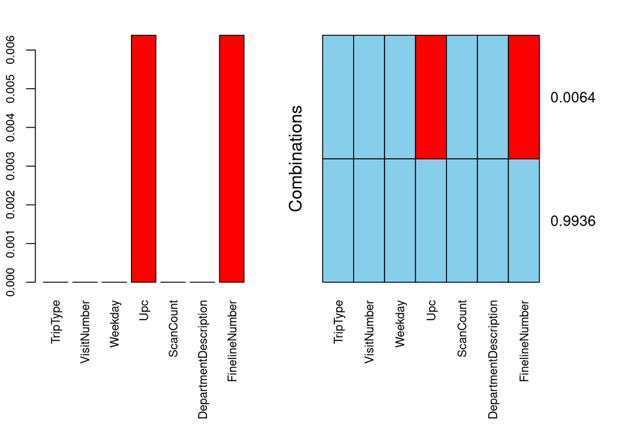

```r
prop_missings(walmart)
```

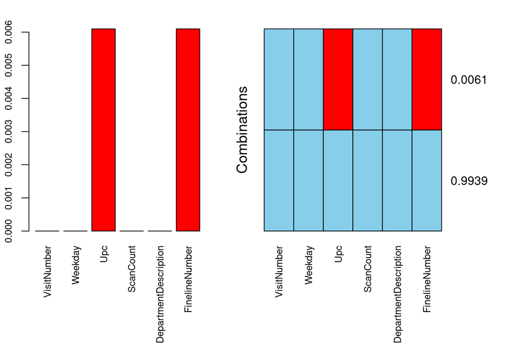

```r
prop_missings(walmart_test)
```

Entonces, por el momento, decidimos quedarnos en estas observaciones incompletas pues creemos que pueden aportar información importante para la predicción de estos datos incompletos.

En adelante, nos enfocaremos sólo en el conjunto de entrenamiento.

Analicemos ahora cuántos valores únicos existen para cada una de las variables.

```r
unique_per_col(walmart)
```

```
##              TripType           VisitNumber               Weekday
##                    38                 95674                     7
##                   Upc             ScanCount DepartmentDescription
##                 97715                    39                    69
##        FinelineNumber
##                  5196
```

Y vemos que para tener más de 600 mil observaciones, hay variables que tienen muy pocos valores únicos por lo que algunas de ellas deben de ser variables categóricas.

Observando más detenidamente el dataframe notamos que hay algunos valores en la columna de DepartmentDescription que tienen “NULL” como valor. Puede que esto se trate de un error que se dio al cambiar los datos de formato. Veamos cuantas observaciones presentan este problema:

```r
rows_with_string(walmart, walmart$DepartmentDescription, 'NULL')
```

```
## # A tibble: 1,361 x 7
##    TripType VisitNumber Weekday   Upc ScanCount DepartmentDescri… FinelineNumber
##       <dbl>       <dbl> <chr>   <dbl>     <dbl> <chr>                      <dbl>
##  1       26           8 Friday     NA         1 NULL                          NA
##  2       27         259 Friday     NA         3 NULL                          NA
##  3       27         259 Friday     NA         1 NULL                          NA
##  4      999         409 Friday     NA        -1 NULL                          NA
##  5       39         479 Friday     NA         1 NULL                          NA
##  6      999         484 Friday     NA        -2 NULL                          NA
##  7      999         484 Friday     NA        -2 NULL                          NA
##  8       32         845 Friday     NA         1 NULL                          NA
##  9       32         845 Friday     NA         1 NULL                          NA
## 10       40        1004 Friday     NA         1 NULL                          NA
## # … with 1,351 more rows
```

Y parece que todas las observaciones con “NULL” en la columna de DepartmentDescription pertenecen al conjunto de observaciones que vimos donde tanto UPC como FinelineNumber son nulas.

Por otra parte, es obvio que hay variables que se leyeron como un tipo cuando en realidad son otro, por ejemplo los días de la semana que se guardaron como caracter pero en realidad son categóricas, entre otros.

Finalmente, los nombres de las columnas están bien pero por convención es mejor tenerlos en minúsculas y separados por un guión bajo ’_’.

Estos tres problemas anteriores se resolverán con una primera iteración de limpieza.

## Limpieza

Primero, pasamos a snake_case los nombres de las columnas y se los asignamos a su variable correspondiente.

```r
colnames(walmart) <- clean_colnames(walmart_colnames)
```

```r
head(walmart)
```

```
## # A tibble: 6 x 7
##   trip_type visit_number weekday     upc scan_count department_desc…
##       <dbl>        <dbl> <chr>     <dbl>      <dbl> <chr>
## 1       999            5 Friday  6.81e10         -1 FINANCIAL SERVI…
## 2        30            7 Friday  6.05e10          1 SHOES
## 3        30            7 Friday  7.41e 9          1 PERSONAL CARE
## 4        26            8 Friday  2.24e 9          2 PAINT AND ACCES…
## 5        26            8 Friday  2.01e 9          2 PAINT AND ACCES…
## 6        26            8 Friday  2.01e 9          2 PAINT AND ACCES…
## # … with 1 more variable: fineline_number <dbl>
```

Ahora, transformemos los “NULL” de la columna de department_description a NA.

```r
walmart$department_description <- replace_NULLs(walmart$department_description)
```

y la proporcion de valores faltantes resulta ahora:

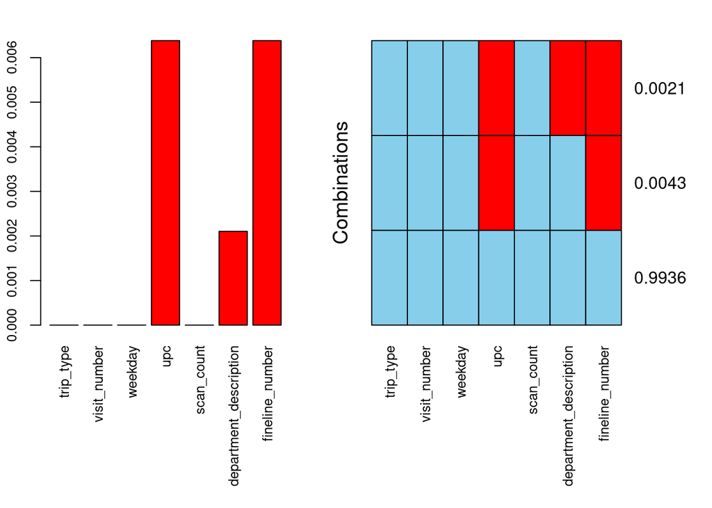

```r
prop_missings(walmart)
```

Finalmente, asignemos el tipo de variable correcto a cada una de las columnas.

```r
walmart <- data_type_conv(walmart)
```

Checamos que se asignaron correctamente los tipos de datos:

```r
glimpse(walmart)
```

```
## Rows: 647,054
## Columns: 7
## $ trip_type              <fct> 999, 30, 30, 26, 26, 26, 26, 26, 26, 26, 26, 2…
## $ visit_number           <dbl> 5, 7, 7, 8, 8, 8, 8, 8, 8, 8, 8, 8, 8, 8, 8, 8…
## $ weekday                <fct> Friday, Friday, Friday, Friday, Friday, Friday…
## $ upc                    <dbl> 68113152929, 60538815980, 7410811099, 22384035…
## $ scan_count             <dbl> -1, 1, 1, 2, 2, 2, 1, 1, 1, -1, 1, 2, 1, 1, -1…
## $ department_description <fct> FINANCIAL SERVICES, SHOES, PERSONAL CARE, PAIN…
## $ fineline_number        <fct> 1000, 8931, 4504, 3565, 1017, 1017, 1017, 2802…
```

Por otra, analizando más de cerca la columna de department_description, notamos que hay un departamento con dos nombres “MENS WEAR” y “MENSWEAR”, unifiquemos estos nombres.

```r
walmart <- walmart %>%
  mutate(department_description = str_replace(department_description, "MENS WEAR", "MENSWEAR"))
```

Y aplicamos este mismo proceso de limpieza al conjunto de prueba.

```r
colnames(walmart_test) <- colnames(walmart_test) %>% clean_colnames()
walmart_test$department_description <- replace_NULLs(walmart_test$department_description)
walmart_test <- data_type_conv(walmart_test)

walmart_test <- walmart_test %>%
  mutate(department_description = str_replace(department_description, "MENS WEAR", "MENSWEAR"))
```

Checamos el resultado:

```r
head(walmart_test)
```

```
## # A tibble: 6 x 6
##   visit_number weekday        upc scan_count department_descrip… fineline_number
##          <dbl> <fct>        <dbl>      <dbl> <chr>               <fct>
## 1            1 Friday     7.25e10          1 SHOES               3002
## 2            1 Friday     1.71e 9          1 DAIRY               1526
## 3            1 Friday     8.95e10          1 DAIRY               1431
## 4            1 Friday     8.85e10          1 GROCERY DRY GOODS   3555
## 5            2 Friday     2.84e 9          1 DSD GROCERY         4408
## 6            2 Friday     7.87e 9          1 BAKERY              5019
```

## EDA univariado

Separemos las variables por categóricas y numéricas, pues los análisis gráficos de cada tipo de variable es diferente.

```r
walmart_num <- select_numeric(walmart)
walmart_cat <- select_categoric(walmart)
```

Ahora graficamos las distintas variables para detectar características importantes de cada una, comenzando por las variables numéricas.

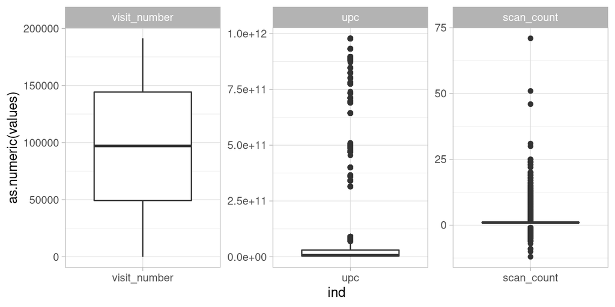

```r
plot_boxplot(walmart_num)
```

Inmediatamente notamos que tanto las variables de upc como scan_count tienen una alta dispersión y recordemos que upc es una de las variables que presentaba datos faltantes, por lo que más adelante en el proceso de limpieza no sería conveniente realizar una imputación por valores medios.

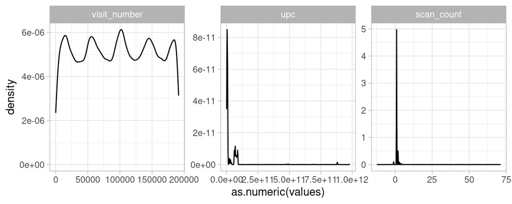

```r
plot_density(walmart_num)
```

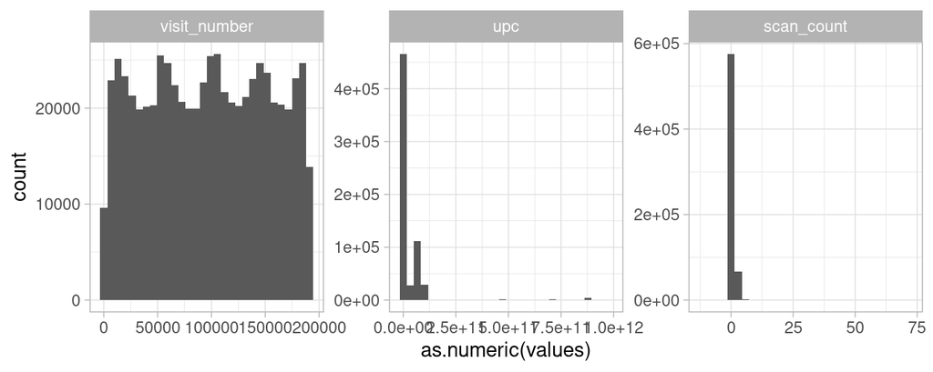

```r
plot_histogram(walmart_num)
```

Tanto en las gráficas de densidad como en los histogramas se observan comportamientos en las variables que no se veían antes como que upc y scan_acount tienden a aglomerarse cerca de un valor, lo cual explica la alta dispersión que vimos en los boxplots.

Por otra parte, visit_number parecería tener un cierto comportamiento periódico con un pico que se repite aproximadamene cada 50 000 valores

Continuemos con el EDA de las variables categóricas.

Para la variable department_description:

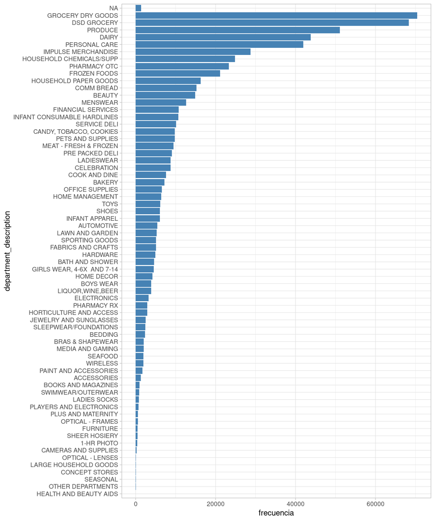

```r
plot_barplot(walmart, walmart$department_description) + theme_light(base_size = 9) +
  xlab("department_description")
```

Los productos comprados más frecuentemente son departamento de comestibles, seguidos por los de cuidado personal y las compras de impulso. Mientras que el menor número de ventas se realizan en los departamentos de auxiliares de salud y belleza y otros departamentos.

Para la variable trip_type:

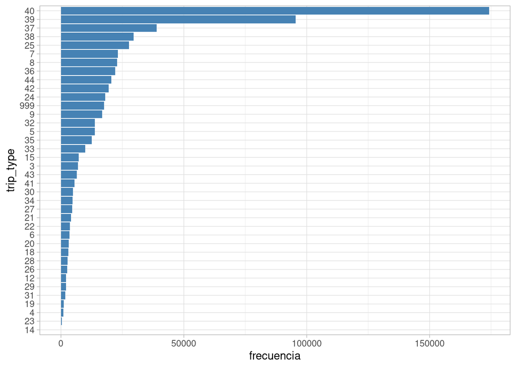

```r
plot_barplot(walmart, walmart$trip_type) + xlab("trip_type")
```

El trip_type más común es el 40, seguido por el 39,37 y 38. Mientras que el menos común es el tipo 14.

Para la variable de weekday:

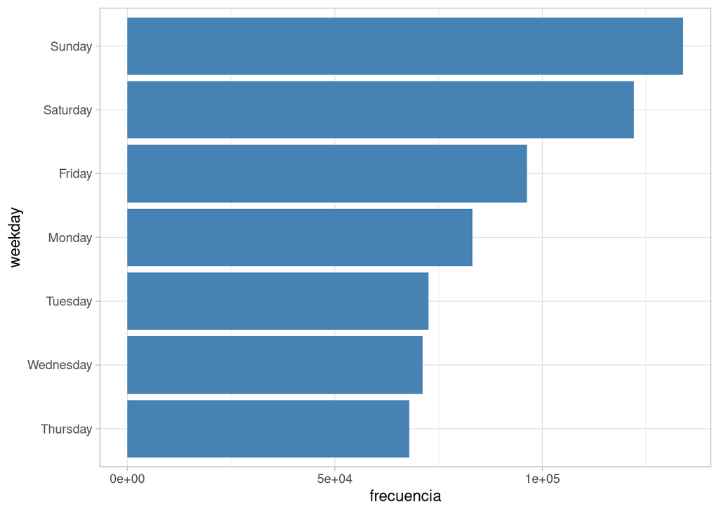

```r
plot_barplot(walmart, walmart$weekday) + xlab("weekday")
```

Los días más comunes para hacer compras son los fines de semana, en especial los domingos, lo cual es congruente con que la mayoría de las personas trabajan los días entre semana. Curiosamente, el día menos común para hacer las compras es el Jueves.

```r
names(sort(summary(walmart$fineline_number), decreasing=T)[1:25])
```

```
##  [1] "(Other)" "5501"    "1508"    "135"     "808"     "NA's"    "0"
##  [8] "9546"    "1407"    "4606"    "115"     "203"     "100"     "3004"
## [15] "4010"    "3601"    "3600"    "110"     "3120"    "3555"    "8101"
## [22] "5017"    "801"     "7010"    "5620"
```

Recordemos que tenemos varias observaciones incompletas a las cuales les faltan dos o tres variables. Nos gustaría analizar más de cerca estas observaciones y ver si se comportan de la misma manera que las demás o si tienen alguna característica que las diferencie además de la incompletez.

Para las variables numéricas:

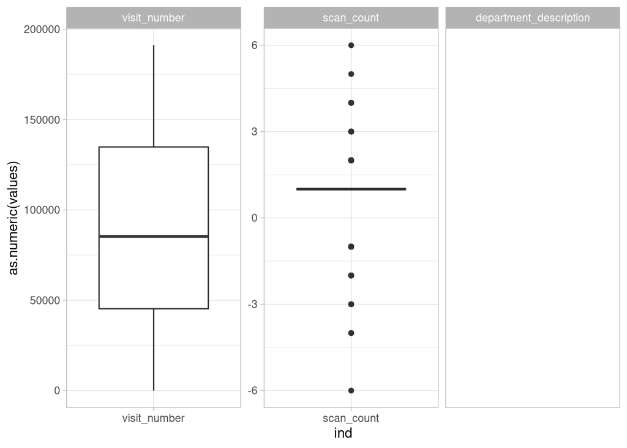

```r
walmart_NA <- rows_with_NAs(walmart)

#plot_boxplot(walmart_NA)

walmart_NA %>% stack() %>% drop_na(values) %>% ggplot(aes(x = ind, y = as.numeric(values))) +
    geom_boxplot() + theme_light() + theme_light() +
    facet_wrap(~ind, scale="free")
```

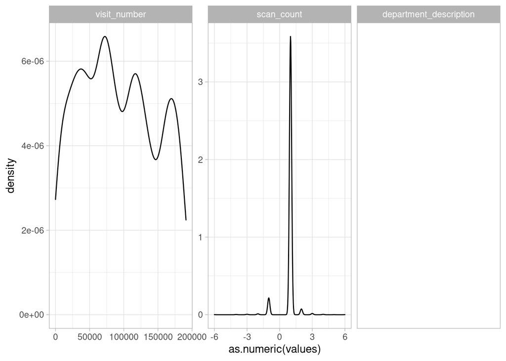

```r
plot_density(walmart_NA)
```

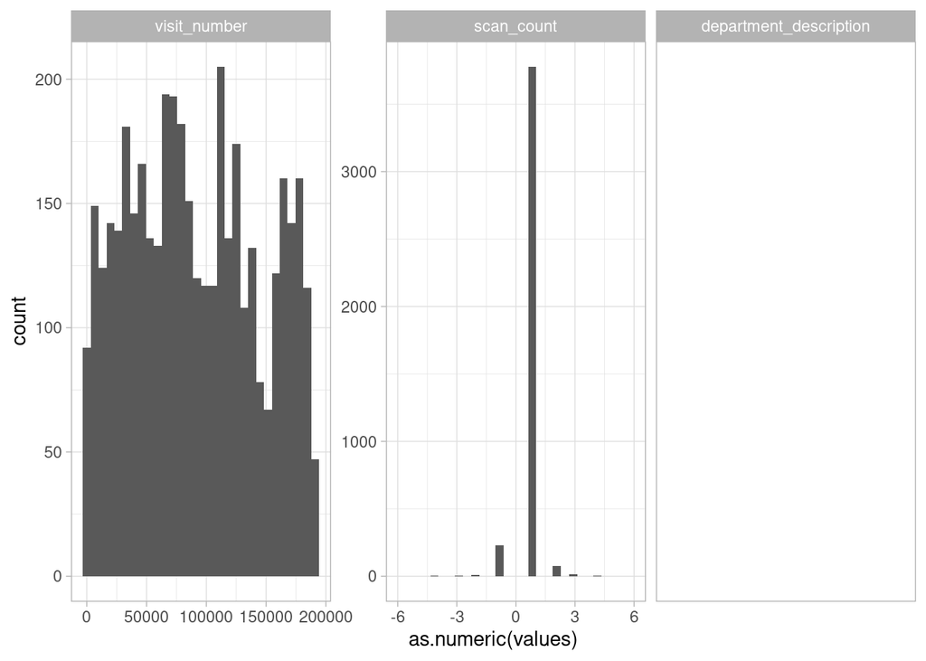

```r
plot_histogram(walmart_NA)
```

El comportamiento de visit_number y la aglomeración al rededor del 1 en scan_account son similares a los vistos en las observaciones completas.

Para las variables categóricas:

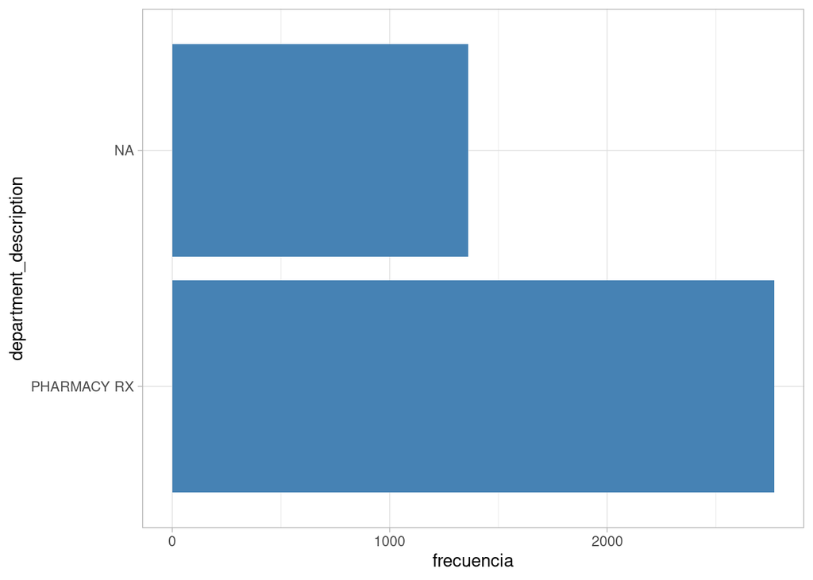

```r
plot_barplot(walmart_NA, walmart_NA$department_description) + xlab("department_description")
```

Así, encontramos una relación entre las observaciones con valores faltantes. Si la observación es incompleta, entonces es muy probable que la compra se haya realizado en el departamento de PHARMACY RX.

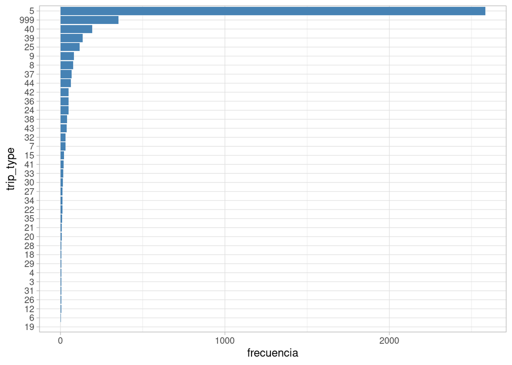

```r
plot_barplot(walmart_NA, walmart_NA$trip_type) + xlab("trip_type")
```

Nuevamente, vemos un cambio en el comportamiento de las observaciones incompletas. Ahora el trip_type más común por mucho es el tipo 5 seguido del 999 que representa otros.

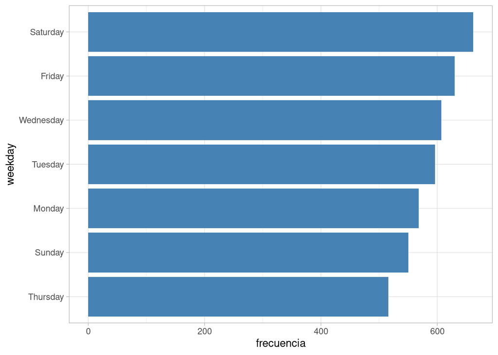

```r
plot_barplot(walmart_NA, walmart_NA$weekday) + xlab("weekday")
```

La variación entre los días de la semana no parece tener un patrón definido en estas observaciones incompletas, pues la frecuencia de los días de la semana no varía considerablemente. Pero algo interesante es que para las completas el día más común era el domingo y este día en las incompletas resulta ser el penúltimo.

Y no podemos hacer un análisis de fineline_number pues todas las observaciones con NA’s tienen valores faltantes en esta columna.

## EDA Bivariado

Correlación de las columnas con la variable de salida:

Empezamos haciendo un análisis de correlación entre las variables numéricas. En particular, nos interesa destacar las variables que tienen una alta correlación positiva o negativa, con la variable trip_type, que es la variable a predecir.

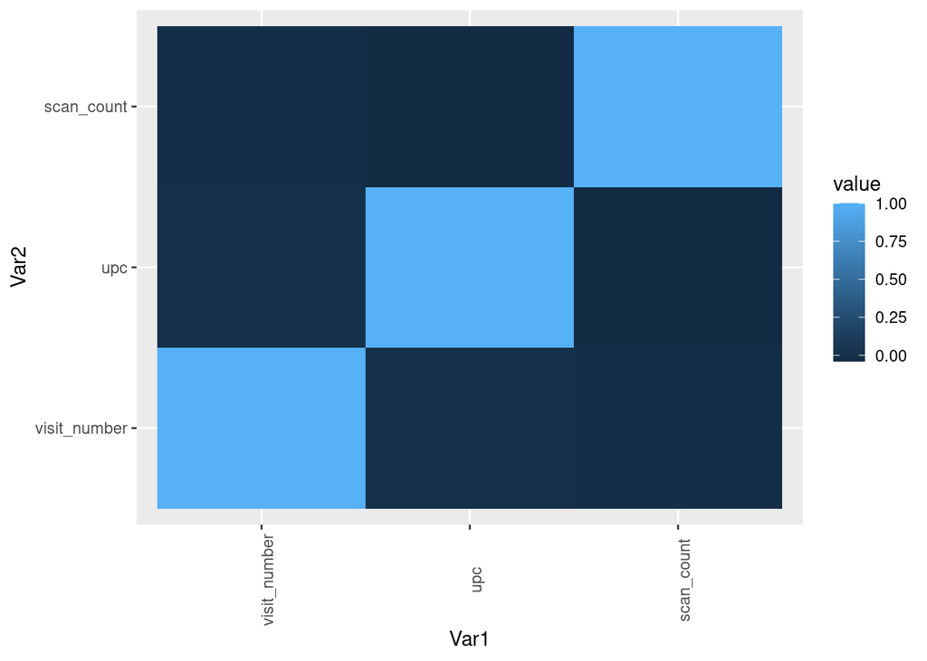

```r
#Las variables numericas
walmart_numeric<-walmart %>% select(where(is.numeric))

## Correlacion entre variables numericas
cor_matrix<-round(cor(walmart_numeric, use="complete.obs" ),2)

melted_walmart <- melt(cor_matrix)

heat_cor_numeric_walmart<-ggplot(data = melted_walmart, aes(x=Var1, y=Var2, fill=value)) +
  geom_tile()+
  theme(axis.text.x = element_text(angle=90))

heat_cor_numeric_walmart
```

No se encuentran fuertes correlaciones entre las variables numéricas.

Para la variable weekday:

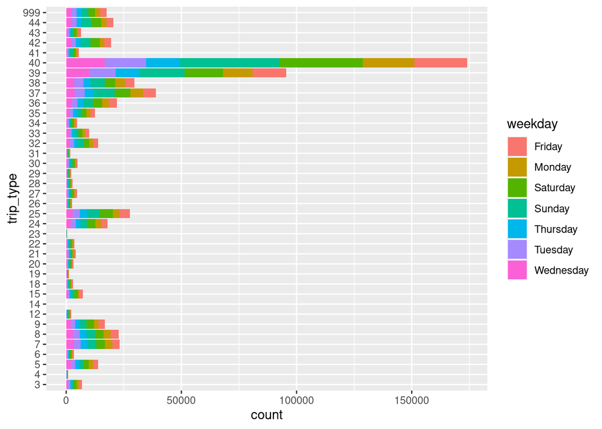

```r
# stacked bar chart
ggplot(walmart, aes(x =trip_type   , fill =  weekday)) +
  geom_bar(position = "stack") + coord_flip()
```

Para la variable scan_count:

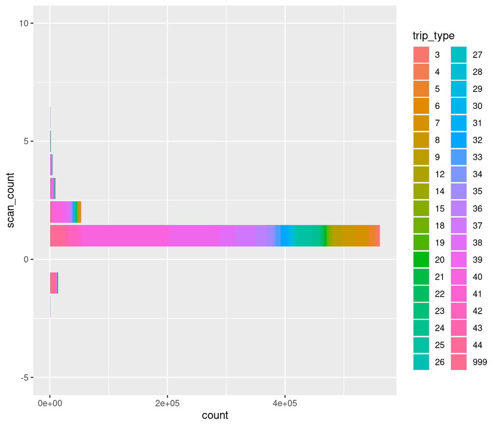

```r
ggplot(walmart, aes(x = scan_count    , fill =trip_type  )) +
  geom_bar(position = "stack") + coord_flip() + xlim(-5, 10)
```

Para la variable department_description:

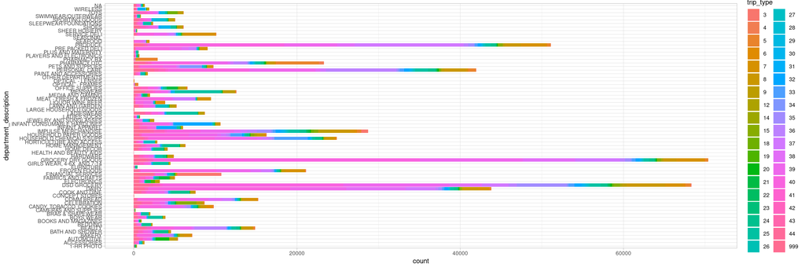

```r
ggplot(walmart, aes(x = department_description, fill =trip_type  )) +
  geom_bar(position = "stack") + coord_flip() + theme_light(base_size = 9)
```

Adicionalmente, se adjunta shinny app que contiene gráficos bivariados de variables numéricas y categóricas y de variables numéricas. A continuación se presentan algunas capturas de pantalla de las gráficas que se pueden generar en esta app.

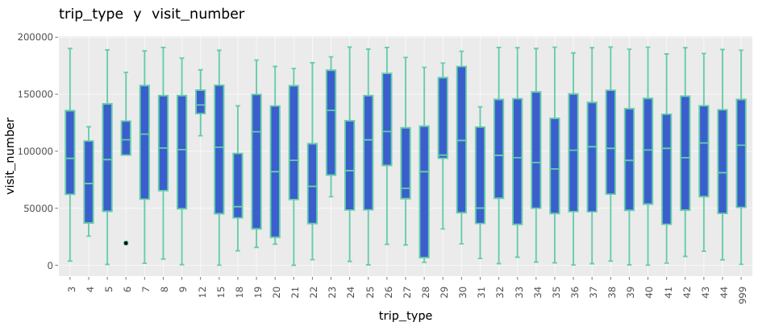

```r
include_graphics('imagenes/trip_type_visit_number.png')
```

Abajo observamos una relación entre tipo de viaje y finleine_number. Esta variación es esperable dado que suponemos que habrá una relación entre el tipo de viaje y comprar productos de una categoría en particular.

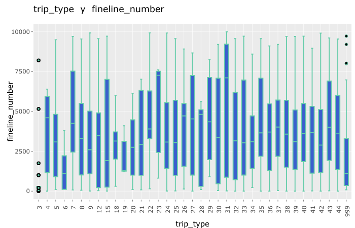

```r
include_graphics('imagenes/trip_type_fineline_number.png')
```

Además, nos gustaría comprender un poco más la clasificación de los trip_types observando de manera más clara las relaciones que existen entre los trip_types y las department_descriptions.

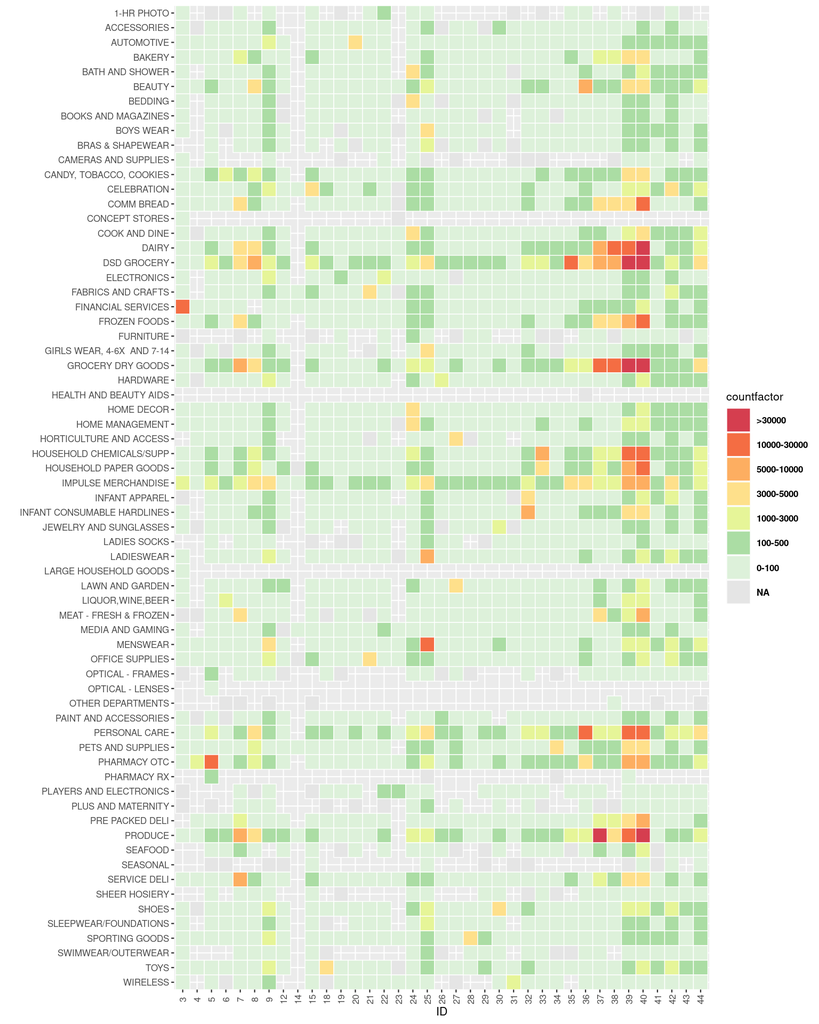

```r
plot_heatmap(walmart)
```

```r
walmart["department_description"][is.na(walmart["department_description"])] <- 'PHARMACY RX'
walmart_test["department_description"][is.na(walmart_test["department_description"])] <- 'PHARMACY RX'
```

Para finalizar el proceso de limpieza y recordando que el proceso de modelado y selección de modelos se realizará en python, se escriben archivos feather con nuestros data sets limpios.

```r
library(feather)
write_feather(walmart,"feathers/walmart.feather")
write_feather(walmart_test,"feathers/walmart_test.feather")
```

# Ingeniería de Características

Ahora, hacemos algunas manipulaciones a las columnas originales para facilitar el modelado posterior en python.

En esta primera parte se crean variables dummies a partir de la columna department_description. Aquí además de las variables dummies creamos las variables de compras o devoluciones por departamento y una columna donde indica si en esa visita se realizó una devolución o no. También creamos una variable donde se indica la cantidad total de productos que se compraron. Al crear estas variables, cambiamos el nivel de análisis, ahora cada observación corresponderá a un viaje a walmart, haciendo un data frame en versión wide.

Posteriormente, creamos la variable de variedad para después unirla al dataser original, esta variable indica en cuántos diferentes departamentos se realizó alguna compra o devolución por visita. Una vez que tenemos nuestra nueva columna de variedad, podemos agregarla al dataset original.

```r
#source("aux-R/04-to-wider.R"    , encoding = 'UTF-8')
```

Nuevamente, recordando que el modelado se hará en python, se pasan los datos a un formato feather.

```r
#write_feather(walmart,"feathers/walmart_wider.feather")
```